# Graphs

## Minimum Spanning Tree

Minimum Spanning Tree algorithm is to find a Tree that connect all the nodes within a connected graph while the sum of edges weight is minimum.

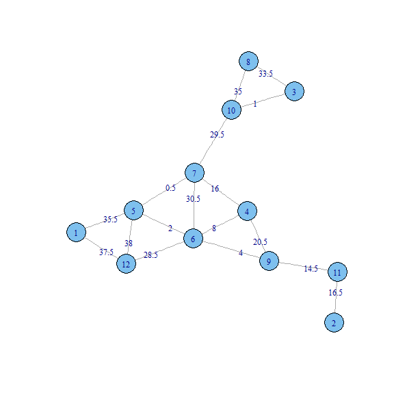

```r
# Create the graph and assign random edge weights
g <- erdos.renyi.game(12, 0.35)
E(g)$weight <- round(runif(length(E(g))),2) * 50
plot(g, layout=layout.fruchterman.reingold,  edge.label=E(g)$weight)
```

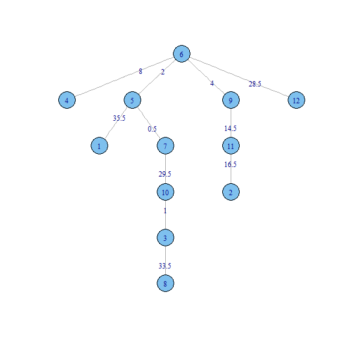

```r
# Compute the minimum spanning tree
mst <- minimum.spanning.tree(g)
plot(mst, layout=layout.reingold.tilford, edge.label=E(mst)$weight)
```

## Clustering

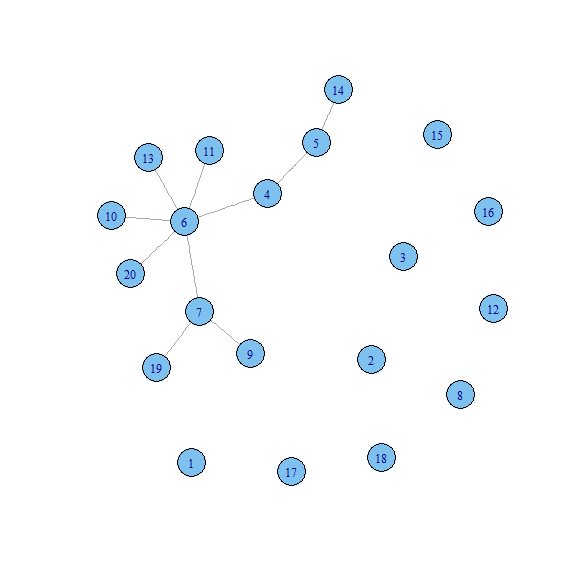

```r
g <- erdos.renyi.game(20, 1/20)
plot(g)
```

```r
clusters(g)
```

```
$membership
 [1]  1  2  3  4  4  4  4  5  4  4  4  6  4  4  7  8  9 10  4  4

$csize
 [1]  1  1  1 11  1  1  1  1  1  1

$no
[1] 10
```

```r
# membership: numeric vector giving the cluster id to which each vertex belongs.
# csize: numeric vector giving the sizes of the clusters.
# no: numeric constant, the number of clusters
```

## Subcomponents

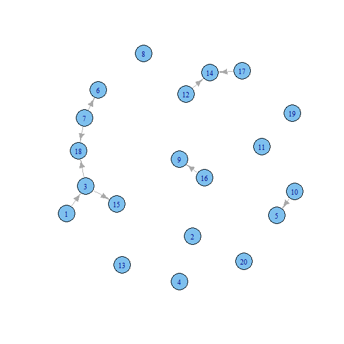

```r
# subcomponent() finds all vertices reachable from a given vertex, or the opposite: all vertices from which a given vertex is reachable via a directed path.

set.seed(100)
g <- erdos.renyi.game(20, 1/50, directed=TRUE)
plot(g)
```

```r
subcomponent(g, 3, "in")
```

```
[1] 3 1
```

```r
subcomponent(g, 3, "out")
```

```
[1]  3 15 18
```

```r
subcomponent(g, 3, "all")
```

```
[1]  3  1 15 18  7  6
```

## Graph Statistics

There are many statistics that we can look to get a general ideas of the shape of the graph. At the highest level, we can look at summarized statistics of the graph. This includes

- Size of the graph (number of nodes and edges)
- Density of the graph measure weither the graph dense (|E| proportional to |V|<sup>2)</sup> or sparse (|E| proportional to |V|) ?
- Is the graph very connected (large portion of nodes can reach each other), or is it disconnected (many islands) ?
- Diameter of the graph measure the longest distance between any two nodes
- Reciprocity measures in a directed graph, how symmetric the relationships are
- Distribution of in/out “degrees”

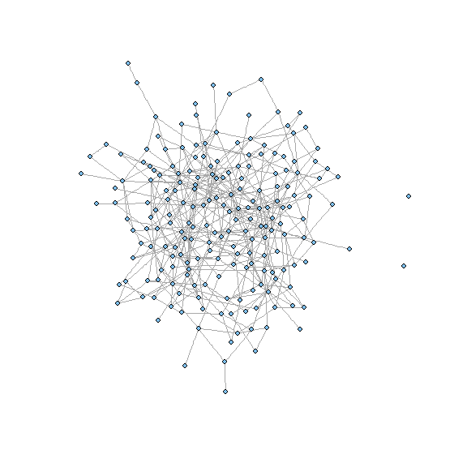

```r
set.seed(121)
# Create a random graph
g <- erdos.renyi.game(200, 0.02)
plot(g, layout=layout.fruchterman.reingold,
       vertex.label=NA, vertex.size=3)
```

```r
# No of nodes
length(V(g))
```

```
[1] 200
```

```r
# No of edges
length(E(g))
```

```
[1] 401
```

```r
# Density (No of edges / possible edges)
graph.density(g)
```

```
[1] 0.02015
```

```r
# Number of islands
clusters(g)$no
```

```
[1] 3
```

```r
# Global cluster coefficient:
#(close triplets/all triplets)
transitivity(g, type="global")
```

```
[1] 0.02846
```

```r
# Edge connectivity, 0 since graph is disconnected
edge.connectivity(g)
```

```
[1] 0
```

```r
# Same as graph adhesion
graph.adhesion(g)
```

```
[1] 0
```

```r
# Diameter of the graph
diameter(g)
```

```
[1] 10
```

```r
# Reciprocity of the graph
reciprocity(g)
```

```
[1] 1
```

```r
# Diameter of the graph
diameter(g)
```

```
[1] 10
```

```r
# Reciprocity of the graph
reciprocity(g)
```

```
[1] 1
```

Drill down a level, we can also look at statistics of each pair of nodes, such as …

- Connectivity between two nodes measure the distinct paths with no shared edges between two nodes. (ie: how much edges need to be removed to disconnect them)
- Shortest path between two nodes
- Trust between two nodes (a function of number of distinct path and distance of each path)

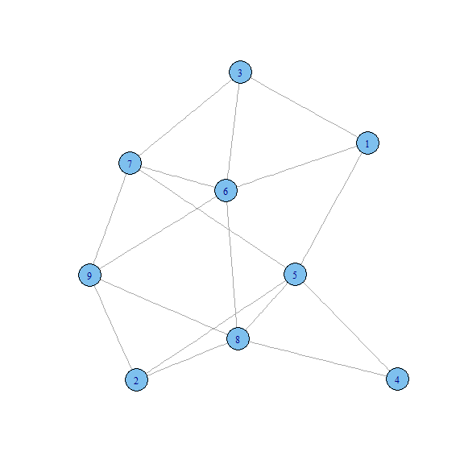

```r
# Create a random graph
g <- erdos.renyi.game(9, 0.5)
plot(g, layout=layout.fruchterman.reingold)
```

```r
# Compute the shortest path matrix
shortest.paths(g)
```

```
      [,1] [,2] [,3] [,4] [,5] [,6] [,7] [,8] [,9]
 [1,]    0    2    1    2    1    1    2    2    2
 [2,]    2    0    3    2    1    2    2    1    1
 [3,]    1    3    0    3    2    1    1    2    2
 [4,]    2    2    3    0    1    2    2    1    2
 [5,]    1    1    2    1    0    2    1    1    2
 [6,]    1    2    1    2    2    0    1    1    1
 [7,]    2    2    1    2    1    1    0    2    1
 [8,]    2    1    2    1    1    1    2    0    1
 [9,]    2    1    2    2    2    1    1    1    0
```

```r
M <- matrix(rep(0, 81), nrow=9)
for (i in 1:9) {
  for (j in 1:9) {
    if (i == j) {
      M[i, j] <- -1
    } else {
      M[i, j] <- edge.connectivity(g, i, j)
    }
  }
}
M
```

```
      [,1] [,2] [,3] [,4] [,5] [,6] [,7] [,8] [,9]
 [1,]   -1    3    3    2    3    3    3    3    3
 [2,]    3   -1    3    2    3    3    3    3    3
 [3,]    3    3   -1    2    3    3    3    3    3
 [4,]    2    2    2   -1    2    2    2    2    2
 [5,]    3    3    3    2   -1    5    4    5    4
 [6,]    3    3    3    2    5   -1    4    5    4
 [7,]    3    3    3    2    4    4   -1    4    4
 [8,]    3    3    3    2    5    5    4   -1    4
 [9,]    3    3    3    2    4    4    4    4   -1
```

## Centrality Measures

At the fine grain level, we can look at statistics of individual nodes. Centrality score measure the social importance of a node in terms of how “central” it is based on a number of measures

- Degree centrality gives a higher score to a node that has a high in/out-degree
- Closeness centrality gives a higher score to a node that has short path distance to every other nodes
- Betweenness centrality gives a higher score to a node that sits on many shortest path of other node pairs
- Eigenvector centrality gives a higher score to a node if it connects to many high score nodes
- Local cluster coefficient measures how my neighbors are inter-connected with each other, which means the node becomes less important.

```r
# Degree
degree(g)
```

```
[1] 3 3 3 2 5 5 4 5 4
```

```r
# Closeness (inverse of average dist)
closeness(g)
```

```
[1] 0.07692 0.07143 0.06667 0.06667 0.09091 0.09091 0.08333 0.09091 0.08333
```

```r
# Betweenness
betweenness(g)
```

```
[1] 1.3667 0.3333 0.3333 0.0000 6.2333 4.4000 2.4000 4.2000 1.7333
```

```r
# Local cluster coefficient
transitivity(g, type="local")
```

```
[1] 0.3333 0.6667 0.6667 1.0000 0.2000 0.4000 0.3333 0.4000 0.5000
```

```r
# Eigenvector centrality
evcent(g)$vector
```

```
[1] 0.6350 0.7004 0.6231 0.4782 0.9168 1.0000 0.8571 0.9960 0.8884
```

```r
# Now rank them
order(degree(g))
```

```
[1] 4 1 2 3 7 9 5 6 8
```

```r
order(closeness(g))
```

```
[1] 3 4 2 1 7 9 5 6 8
```

```r
order(betweenness(g))
```

```
[1] 4 2 3 1 9 7 8 6 5
```

```r
order(evcent(g)$vector)
```

```
[1] 4 3 1 2 7 9 5 8 6
```

From his studies, Drew Conway has found that people with low Eigenvector centrality but high Betweenness centrality are important gate keepers, while people with high Eigenvector centrality but low Betweenness centrality has direct contact to important persons. So lets plot Eigenvector centrality against Betweenness centrality.

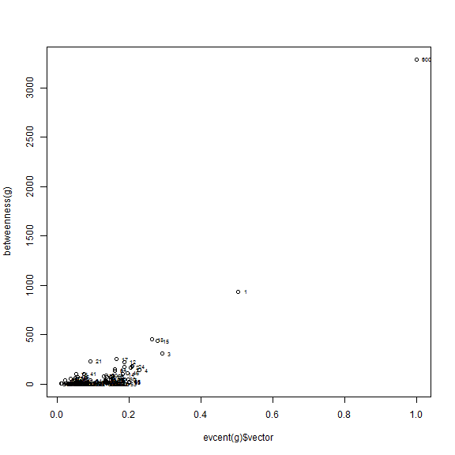

```r
# Create a graph
g1 <- barabasi.game(100, directed=F)
g2 <- barabasi.game(100, directed=F)
g <- g1 %u% g2 # union of the two graphs, only edges which are included in at least one graph will be part of the new graph
lay <- layout.fruchterman.reingold(g)
# Plot the eigevector and betweenness centrality
plot(evcent(g)$vector, betweenness(g))
text(evcent(g)$vector, betweenness(g), 0:100,
       cex=0.6, pos=4)
```

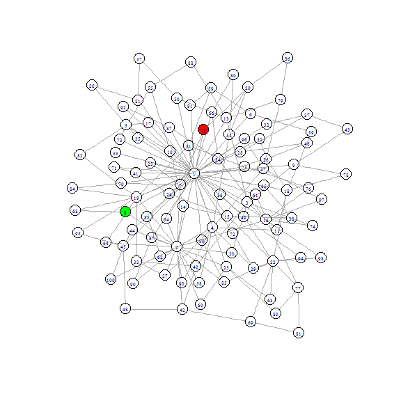

```r
V(g)[12]$color <- 'red'
V(g)[8]$color <- 'green'
plot(g, layout=lay, vertex.size=8,vertex.label.cex=0.6)
```

## More info

- https://sites.google.com/site/daishizuka/toolkits/sna/igraph-vs-statnet